# CS 422

Sneha Shahaji Kadam

### Part 2.1 (a)

```r
df <- read.csv("College.csv", header=T,row.names=1)
firstfive <- df[1:5,c(1,5,8,10)]
firstfive
```

|  | Private | Top10perc | P.Undergrad | Room.Board |
| --- | --- | --- | --- | --- |
| Abilene Christian University | Yes | 23 | 537 | 3300 |
| Adelphi University | Yes | 16 | 1227 | 6450 |
| Adrian College | Yes | 22 | 99 | 3750 |
| Agnes Scott College | Yes | 60 | 63 | 5450 |
| Alaska Pacific University | Yes | 16 | 869 | 4120 |

### Part 2.1 (b)

```r
library(dplyr)
private <- nrow(select(filter(df, Private == "Yes")))
public <- nrow(select(filter(df, Private == "No")))
str <- paste("There are ",private,"private colleges and ", public,"public collges")
str
```

```
[1] "There are  565 private colleges and  212 public collges"
```

### Part 2.1 (c)

```r
newdataframe <- df[,c("Private","Apps","Accept","Enroll","PhD","perc.alumni","S.F.Ratio","Grad.Rate")]
newdf <- head(newdataframe)
newdf
```

|  | Private | Apps | Accept | Enroll | PhD | perc.alumni | S.F.Ratio | Grad.Rate |
| --- | --- | --- | --- | --- | --- | --- | --- | --- |
| Abilene Christian University | Yes | 1660 | 1232 | 721 | 70 | 12 | 18.1 | 60 |
| Adelphi University | Yes | 2186 | 1924 | 512 | 29 | 16 | 12.2 | 56 |
| Adrian College | Yes | 1428 | 1097 | 336 | 53 | 30 | 12.9 | 54 |
| Agnes Scott College | Yes | 417 | 349 | 137 | 92 | 37 | 7.7 | 59 |
| Alaska Pacific University | Yes | 193 | 146 | 55 | 76 | 2 | 11.9 | 15 |
| Albertson College | Yes | 587 | 479 | 158 | 67 | 11 | 9.4 | 55 |

### Part 2.1 (d) (i)

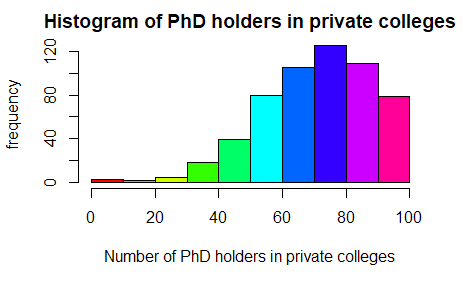

```r
phd.private <- select(filter(newdataframe,Private == "Yes"),"PhD")
hist1 <- hist(phd.private$PhD, main="Histogram of PhD holders in private colleges", xlab="Number of PhD holders in private colleges", ylab="frequency",col=rainbow(10))
```

### Part 2.1 (d) (ii)

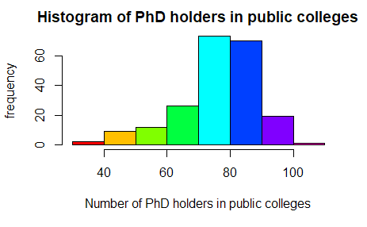

```r
phd.public <- select(filter(newdataframe,Private == "No"),"PhD")
hist2 <- hist(phd.public$PhD, main="Histogram of PhD holders in public colleges", xlab="Number of PhD holders in public colleges", ylab="frequency", col=rainbow(8))
```

### Part 2.1 (e)(i)

```r
min.graduate.rate.colleges <- newdataframe[order(newdataframe$Grad.Rate),]
min <- min.graduate.rate.colleges[c(1:5),]
rownames(min)
```

```
[1] "Texas Southern University"
[2] "Alaska Pacific University"
[3] "Montreat-Anderson College"
[4] "Brewton-Parker College"
[5] "Claflin College"
```

### Part 2.1 (e)(ii)

```r
max.graduate.rate.colleges <- newdataframe[order(-newdataframe$Grad.Rate),]
max <- max.graduate.rate.colleges[c(1:5),]
rownames(max)
```

```
[1] "Cazenovia College"
[2] "Amherst College"
[3] "College of Mount St. Joseph"
[4] "Grove City College"
[5] "Harvard University"
```

### Part 2.1 (f) (i)

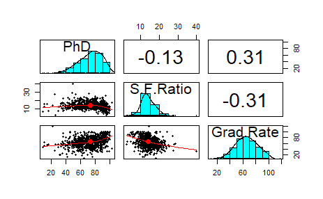

```r
#install.packages("psych")
library(psych)
pairs.panels(newdataframe[,c("PhD","S.F.Ratio","Grad.Rate")])
```

# Part 2.1 (f) (ii) Attributes PhD and Grad.Rate have highest correlation of 0.31.This positive correlation means that PhD decreases as Grad.Rate decreases, similarly PhD increases as Grad.Rate increases.

# Part 2.1 (f) (iii) Attributes S.F.Ratio and Grad.Rate have lowest correlation of -0.31. This negative correlation means that as S.F.Ratio increases in value, Grad.Rate will decrease; similarly, if S.F.Ratio decreases in value, Grad.Rate will increase.

### Part 2.1 (g)

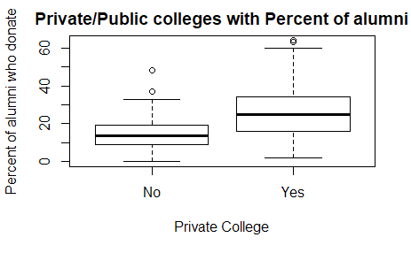

```r
boxplot(df$perc.alumni~df$Private ,data=df,main="Private/Public colleges with Percent of alumni", xlab="Private College",ylab="Percent of alumni who donate")
```

# Alumni of private colleges donate more to their colleges.

### Part 2.1 (h)

```r
summary(df$Expend)
```

```
   Min. 1st Qu.  Median    Mean 3rd Qu.    Max.
   3186    6751    8377    9660   10830   56233
```

```r
cum_dis_fn <- ecdf(df$Expend)
```

### Part 2.1 (h)(iii)

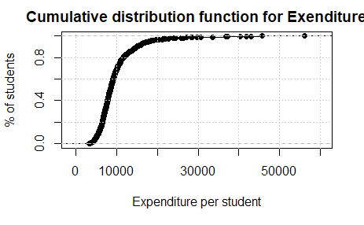

```r
plot <- plot(cum_dis_fn, main="Cumulative distribution function for Exenditure",xlab="Expenditure per student", ylab="% of students")
grid(plot)
```

# Part 2.1 h (i)By looking at the graph,we can say that median expenditure per student is around 8000 dollars. By running summary(df$Expend), we get exact value of median expenditure per student which is 8377 dollars.

# Part 2.1 h (ii) 80% of the students pay less than 12,000 dollars

### Part 2.2(a)

```r
library(ISLR)
data(Auto)
sim_lin_reg <- lm(mpg ~ horsepower, data = Auto)
summary(sim_lin_reg)
```

```
Call:
lm(formula = mpg ~ horsepower, data = Auto)

Residuals:
     Min       1Q   Median       3Q      Max
-13.5710  -3.2592  -0.3435   2.7630  16.9240

Coefficients:
             Estimate Std. Error t value Pr(>|t|)
(Intercept) 39.935861   0.717499   55.66   <2e-16 ***
horsepower  -0.157845   0.006446  -24.49   <2e-16 ***
---
Signif. codes:
0 ‘***’ 0.001 ‘**’ 0.01 ‘*’ 0.05 ‘.’ 0.1 ‘ ’ 1

Residual standard error: 4.906 on 390 degrees of freedom
Multiple R-squared:  0.6059,    Adjusted R-squared:  0.6049
F-statistic: 599.7 on 1 and 390 DF,  p-value: < 2.2e-16
```

#Part 2.2(a)(i) Yes, there is a relationship between horsepower and mpg. This can be determined by testing the null hypothesis of all regression coefficients equal to zero. As the F-statistic is far larger than 1 and the p-value of the F-statistic is close to zero we can reject the null hypothesis and say that there is a statistically significant relationship between horsepower and mpg.

#Part 2.2(a)(ii) The multiple R-squared of the sim_lin_reg(simple linear regression) was about 0.6059. This value indicates that about 60.59% of the variation in the response variable (mpg) is due to the predictor variable (horsepower).

#Part 2.2(a)(iii) As the coeficient of “horsepower” is negative, the relationship between mpg and horsepower is negative. The more horsepower an automobile has the linear regression indicates the less mpg fuel efficiency the automobile will have.

### Part 2.2 (a) (iv)

```r
predict(sim_lin_reg, data.frame(horsepower = 98), interval = "prediction")
```

```
       fit     lwr      upr
1 24.46708 14.8094 34.12476
```

```r
predict(sim_lin_reg, data.frame(horsepower = 98), interval = "confidence")
```

```
       fit      lwr      upr
1 24.46708 23.97308 24.96108
```

### Part 2.2(b)

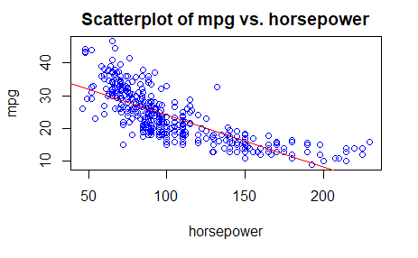

```r
plot(Auto$horsepower, Auto$mpg, main = "Scatterplot of mpg vs. horsepower", xlab = "horsepower", ylab = "mpg", col="blue")
abline(sim_lin_reg,col="red")
```

### Part 2.2 (c)

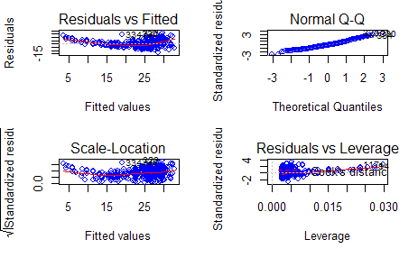

```r
par(mfrow = c(2,2))
plot(sim_lin_reg,col="blue")
```

#The plot of residuals versus fitted values indicates the presence of non-linearity in the data. #The plot of standardized residuals versus leverage indicates the presence of few high leverage points and few outliers (higher than 2 or lower than -2).

### Part 2.3

```r
set.seed(1122)
index <- sample(1:nrow(Auto), 0.95*dim(Auto)[1])
train.df <- Auto[index,]
test.df <- Auto[-index,]
```

### Part 2.3 (a)

```r
multi_reg_model <- lm(mpg~.-name, data = Auto)
```

### Part 2.3 (a)(i)

#name has all unique string values. we can’t categorize them. Therefore, using name as Predictor is not a reasonable thing to do.

### Part 2.3 (a)(ii)

```r
summary(multi_reg_model)
```

```
Call:
lm(formula = mpg ~ . - name, data = Auto)

Residuals:
    Min      1Q  Median      3Q     Max
-9.5903 -2.1565 -0.1169  1.8690 13.0604

Coefficients:
               Estimate Std. Error t value Pr(>|t|)
(Intercept)  -17.218435   4.644294  -3.707  0.00024
cylinders     -0.493376   0.323282  -1.526  0.12780
displacement   0.019896   0.007515   2.647  0.00844
horsepower    -0.016951   0.013787  -1.230  0.21963
weight        -0.006474   0.000652  -9.929  < 2e-16
acceleration   0.080576   0.098845   0.815  0.41548
year           0.750773   0.050973  14.729  < 2e-16
origin         1.426141   0.278136   5.127 4.67e-07

(Intercept)  ***
cylinders
displacement **
horsepower
weight       ***
acceleration
year         ***
origin       ***
---
Signif. codes:
0 ‘***’ 0.001 ‘**’ 0.01 ‘*’ 0.05 ‘.’ 0.1 ‘ ’ 1

Residual standard error: 3.328 on 384 degrees of freedom
Multiple R-squared:  0.8215,    Adjusted R-squared:  0.8182
F-statistic: 252.4 on 7 and 384 DF,  p-value: < 2.2e-16
```

```r
len_co <- length(coefficients(multi_reg_model))
RSS <- c(crossprod(multi_reg_model$residuals))
MSE <- RSS / length(multi_reg_model$residuals)
RMSE <- sqrt(MSE)
paste0("Root mean squared error is ", RMSE)
```

```
[1] "Root mean squared error is 3.2935514183022"
```

#R² is a measure of how close the data is to the fitted regression line. The higher the R-squared, the better the model fits your data. #The RMSE is the square root of the variance of the residuals.Lower values of RMSE indicate better fit. #From above values of R²,RSE and RMSE, we can say that model is a good fit.

### Part 2.3 (a)(iii)

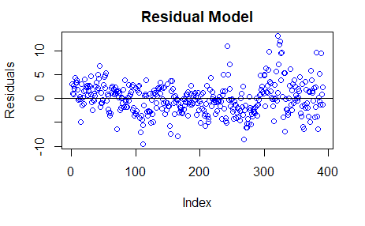

```r
plot(multi_reg_model$residuals, ylab="Residuals", main="Residual Model", col="blue")
abline(0, 0)
```

### Part 2.3 (a)(iv)

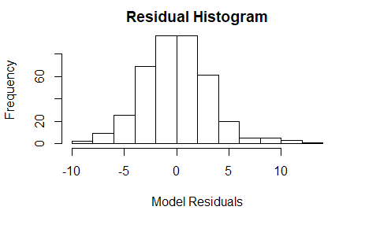

```r
hist(multi_reg_model$residuals,xlab = "Model Residuals",
     main="Residual Histogram")
```

# Yes It’s a gaussian distribution.

# Residuals are normally distributed with two outliers.

### Part 2.3 (b) (i)

# Predictors origin, weight and year are statistically significant than others because they have lowest p value.

```r
multi_reg_model_3pred <- lm(mpg~origin+weight+year, data = Auto)
```

### Part 2.3 (b) (ii)

```r
summary(multi_reg_model_3pred)
```

```
Call:
lm(formula = mpg ~ origin + weight + year, data = Auto)

Residuals:
    Min      1Q  Median      3Q     Max
-9.9440 -2.0948 -0.0389  1.7255 13.2722

Coefficients:
              Estimate Std. Error t value Pr(>|t|)
(Intercept) -1.805e+01  4.001e+00  -4.510 8.60e-06 ***
origin       1.150e+00  2.591e-01   4.439 1.18e-05 ***
weight      -5.994e-03  2.541e-04 -23.588  < 2e-16 ***
year         7.571e-01  4.832e-02  15.668  < 2e-16 ***
---
Signif. codes:
0 ‘***’ 0.001 ‘**’ 0.01 ‘*’ 0.05 ‘.’ 0.1 ‘ ’ 1

Residual standard error: 3.348 on 388 degrees of freedom
Multiple R-squared:  0.8175,    Adjusted R-squared:  0.816
F-statistic: 579.2 on 3 and 388 DF,  p-value: < 2.2e-16
```

```r
len_co2 <- length(coefficients(multi_reg_model_3pred))
RSS2 <- c(crossprod(multi_reg_model_3pred$residuals))
MSE2 <- RSS2 / length(multi_reg_model_3pred$residuals)
RMSE2 <- sqrt(MSE2)
paste0("Root mean squared error is ", RMSE2)
```

```
[1] "Root mean squared error is 3.33048122511762"
```

### Part 2.3 (b) (iii)

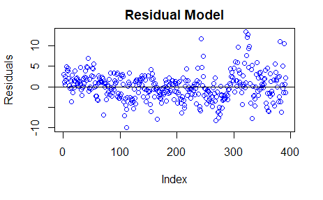

```r
plot( multi_reg_model_3pred$residuals, ylab="Residuals", main="Residual Model", col="blue")
abline(0, 0)
```

#From above values of R²,RSE and RMSE, we can say that model is a good fit.

### Part 2.3 (b) (iv)

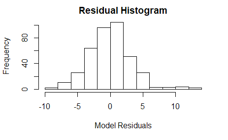

```r
hist(multi_reg_model_3pred$residuals,xlab = "Model Residuals", main="Residual Histogram")
```

# Yes It’s a gaussian distribution.

# Residuals are normally distributed with two outliers.

### Part 2.3 (b) (v)

# Higher R² value means model is better.Therefore model produced in (a) is better because it has higher R² value than (b) .

### Part 2.3 (d)

```r
prediction <- predict.lm(multi_reg_model_3pred ,newdata=select(test.df,c("weight","year","origin")), interval="confidence", level=0.95)

verify_prediction <- data.frame(predicted_values=as.integer(prediction[,1]), actual_values=test.df$mpg)
```

### Part 2.3 (e)

```r
no_of_exact_match <- verify_prediction$predicted_values == verify_prediction$actual_values

final_df <- cbind(test.df$mpg,prediction,no_of_exact_match)

colnames(final_df) <- c("Response","Prediction","Lower","Upper","Matches")

final_df
```

```
    Response Prediction     Lower     Upper Matches
23      25.0  23.017729 22.253369 23.782090       0
86      13.0  13.798863 13.229514 14.368212       1
96      12.0   8.697869  7.815105  9.580633       0
111     22.0  26.415522 25.638216 27.192828       0
121     19.0  22.334007 21.849412 22.818603       0
140     14.0  11.331154 10.579331 12.082977       0
153     19.0  20.324198 19.909999 20.738398       0
161     17.0  16.469980 15.975249 16.964711       0
176     29.0  29.428783 28.851033 30.006533       1
178     23.0  24.891236 24.493787 25.288685       0
179     23.0  23.314783 22.910012 23.719554       1
189     16.0  15.530771 14.928222 16.133320       0
259     20.6  21.900259 21.423809 22.376709       0
279     31.5  31.382473 30.864129 31.900818       0
302     34.2  29.730444 29.021532 30.439356       0
319     29.8  29.725357 28.910187 30.540528       0
343     30.0  30.135784 29.401813 30.869756       1
345     39.0  33.192785 32.311127 34.074442       0
348     37.0  34.894154 34.131377 35.656932       0
359     31.6  30.938037 30.094980 31.781093       0
```

```r
paste0("Total observations correctly predicted: ", sum(no_of_exact_match))
```

```
[1] "Total observations correctly predicted: 4"
```